# Pre-workshop_pop_projection_solutions

Mia Zhong

2022-05-26

## Solutions to Exercise Part 1

1. How would the lifecycle diagram above change if all fish who entered the adult stage died within a year? How would this change affect the Leslie matrix?

The new lifecycle diagram will not have the arrow that points from adults back to adults ($P_{33}$ will be 0).

The new Leslie Matrix will be:

$$A =\begin{bmatrix}
0 & F_2 & F_3 \\
P_{21} & 0 & 0 \\
0 & P_{32} & 0\\
\end{bmatrix} =\begin{bmatrix}
0 & 5 & 10 \\
0.3 & 0 & 0 \\
0 & 0.5 &0 \\
\end{bmatrix}$$

2. Draw a lifecycle diagram for a human population divided into 15-year age groups: 0-14, 15-29, 30-44, 45-59, 60-74, 75+. You can use 15 year time steps and you can assume the population is all female. (Just draw the nodes and arrows; you don’t need quantitative estimates for all of the arrows.)

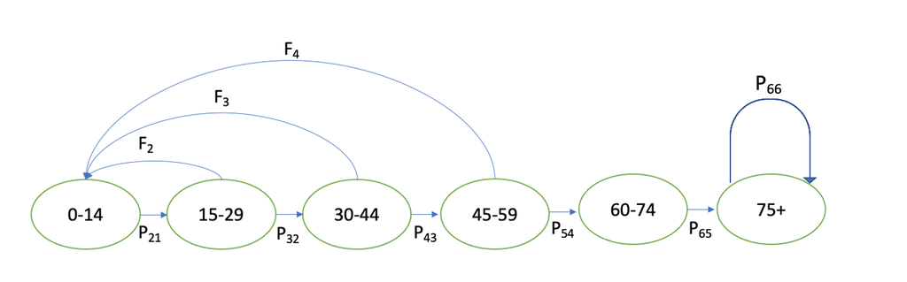

## Solutions to Exercise Part 2

### 1. How would you describe the trajectory of the total population over time? (Is it increasing linearly? Logarithmically? etc)

Looks like the fish population is growing fast, converging to an exponential growth.

### 2.Does there appear to be a long-term equilibrium age structure and growth rate? If so, what are they? If not, how does the growth rate appear to change?

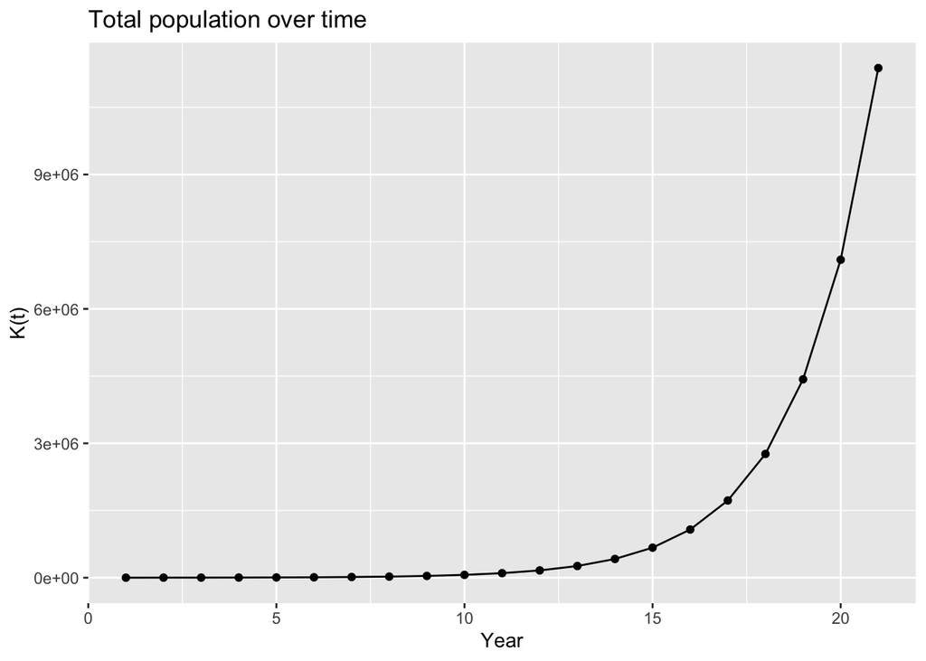

```r
# get K in a form that's easier to ggplot
# make into a dataframe, name columns as years and add an age column
Kdf <- as.data.frame(K.projected)
colnames(Kdf) <- seq(1, to = years+1, by = 1)
Kdf <- cbind(stage = c("Eggs", "Juvenile", "Adult"), Kdf)

# get in long format and then add proportion of population in each age group
# switching between long and wide forms of data is helpful in analyzing the results of matrix analyses

Klong <- Kdf %>%
  gather(year, population, -stage) %>%
  group_by(year) %>%
  mutate(proportion = population/sum(population),
         stage = as.factor(stage))

# total population by year
tot_pop <- Klong %>%
  group_by(year) %>%
  summarise(pop = sum(population)) %>% ungroup()

# plot total population over time
ggplot(data = tot_pop, aes(x = as.numeric(year), y = pop, group = 1)) +
  geom_point() + geom_line()+
  xlab("Year") + ylab("K(t)")+
  ggtitle("Total population over time")
```

Now, let’s look at the growth rate. If we assume exponential growth (more on that during the workshop):

$\textbf{K(t+1)} = \textbf{K (t)} e^{r}$ where $r$ is the growth rate from projecting the population forward one year.

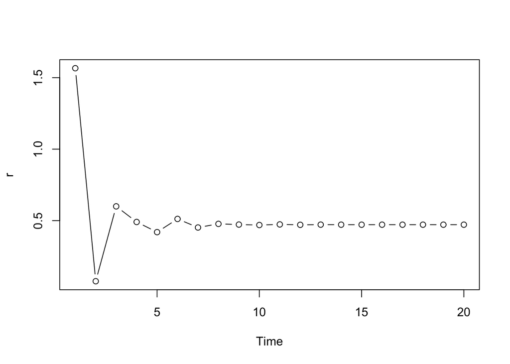

```r
# let's plot using base R so we now how to do it with and without ggplot2

# plot r for each year
tot_pop <- tot_pop %>% arrange(as.numeric(year))
lambPop<-log(tot_pop$pop[2:(years+1)]/tot_pop$pop[1:years])
matplot(1:years, lambPop, type="b", pch=1, ylab = "r", xlab = "Time")
```

Looks like in the long-run, the population grows annually at a constant rate, $r$!

### 3. What happens to the age structure and growth rate if we start with a different intial population and age distribution?

Let’s set up the experiment again, now with a different starting population.

```r
# set up the example
#Leslie Matrix
A <- matrix(c(0, 5, 10, 0.3, 0, 0, 0, 0.5, 0.2 ), nr = 3, byrow = TRUE)

# set up the intial population vector
#K0 <- matrix(c(100,250,50), ncol = 1) # this is the original population we tried
K0 <- matrix(c(50,75,300), ncol = 1) # now we change this vector to a new starting population

years <- 20
K.projected <- matrix(0, nrow = nrow(A), ncol = years+1)
K.projected[, 1] <- K0

for (i in 1:years)
{
    K.projected[, i + 1] <- A %*% K.projected[,i]
}
```

Now lets repeat what we did earlier.

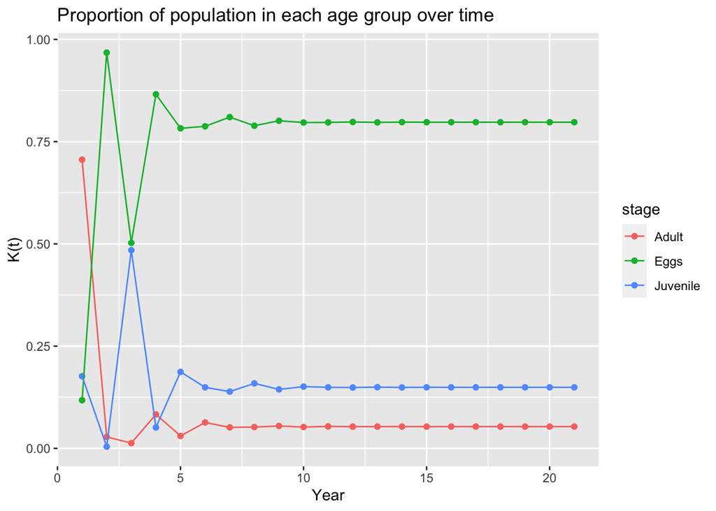

```r
# get K in a form that's easier to ggplot
# make into a dataframe, name columns as years and add an age column
Kdf <- as.data.frame(K.projected)
colnames(Kdf) <- seq(1, to = years+1, by = 1)
Kdf <- cbind(stage = c("Eggs", "Juvenile", "Adult"), Kdf)

# get in long format and then add proportion of population in each age group
Klong <- Kdf %>%
  gather(year, population, -stage) %>%
  group_by(year) %>%
  mutate(proportion = population/sum(population),
         stage = as.factor(stage))


# total population by year
tot_pop <- Klong %>%
  group_by(year) %>%
  summarise(pop = sum(population)) %>% ungroup()

# plot proportion in each age group over time
ggplot(data = Klong, aes(x = as.numeric(year), y = proportion, group = stage, color = stage)) +
  geom_point() + geom_line()+
  xlab("Year") + ylab("K(t)")+
  ggtitle("Proportion of population in each age group over time")
```

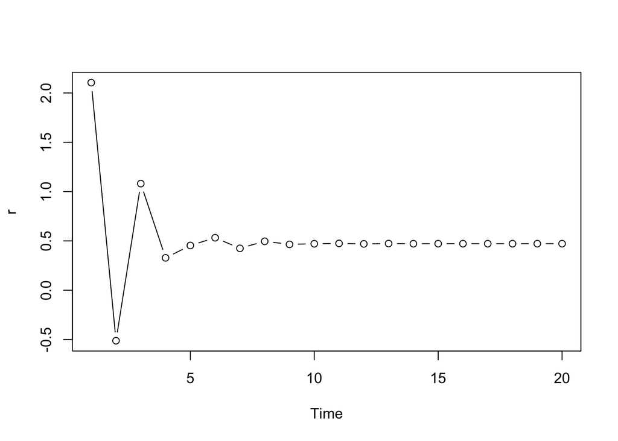

```r
# plot r for each year
tot_pop <- tot_pop %>% arrange(as.numeric(year))
lambPop<-log(tot_pop$pop[2:(years+1)]/tot_pop$pop[1:years])
matplot(1:years, lambPop, type="b", pch=1, ylab = "r", xlab = "Time")
```

Wow! They look nearly identical. This is another key concept of stable population theory - **regardless of the characteristics of the starting population i.e. age structure and size, if constant mortality and fertility rates are applied for a long time, the population will eventually attain the characteristics (long-run $r$ and stable age distribution) that are intrinsic to those rates.**

### 4. What happens to the age structure and growth rate if we multiply the 1st row by a constant like 2?

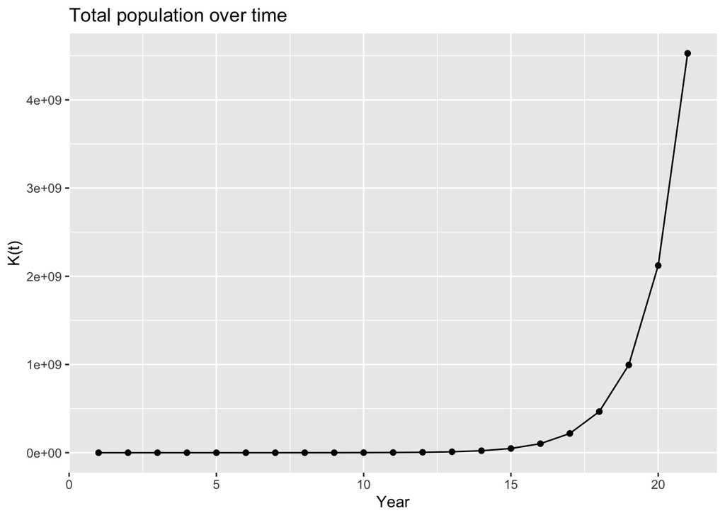

```r
# change the Leslie matrix A as requested
A <- matrix(c(0, 5*2, 10*2, 0.3, 0, 0, 0, 0.5, 0.2 ), nr = 3, byrow = TRUE)

# set up the intial population vector, we can go back to the original example
K0 <- matrix(c(100,250,50), ncol = 1)

years <- 20
K.projected <- matrix(0, nrow = nrow(A), ncol = years+1)
K.projected[, 1] <- K0

for (i in 1:years)
{
    K.projected[, i + 1] <- A %*% K.projected[,i]
}

# then repeat what we did again
# get K in a form that's easier to ggplot
# make into a dataframe, name columns as years and add an age column
Kdf <- as.data.frame(K.projected)
colnames(Kdf) <- seq(1, to = years+1, by = 1)
Kdf <- cbind(stage = c("Eggs", "Juvenile", "Adult"), Kdf)

# get in long format and then add proportion of population in each age group
Klong <- Kdf %>%
  gather(year, population, -stage) %>%
  group_by(year) %>%
  mutate(proportion = population/sum(population),
         stage = as.factor(stage))


# total population by year
tot_pop <- Klong %>%
  group_by(year) %>%
  summarise(pop = sum(population)) %>% ungroup()

# plot total population over time
ggplot(data = tot_pop, aes(x = as.numeric(year), y = pop, group = 1)) +
  geom_point() + geom_line()+
  xlab("Year") + ylab("K(t)")+
  ggtitle("Total population over time")
```

[figure not shown]

```r
# plot proportion in each age group over time
ggplot(data = Klong, aes(x = as.numeric(year), y = proportion, group = stage, color = stage)) +
  geom_point() + geom_line()+
  xlab("Year") + ylab("K(t)")+
  ggtitle("Proportion of population in each age group over time")
```

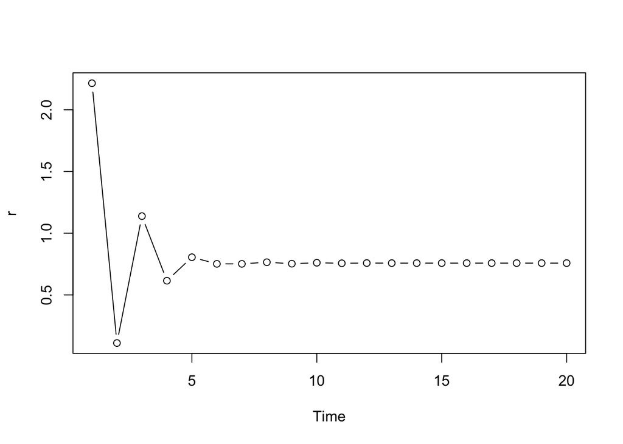

```r
# plot the growth rate r for each year
tot_pop <- tot_pop %>% arrange(as.numeric(year))
lambPop<-log(tot_pop$pop[2:(years+1)]/tot_pop$pop[1:years])
matplot(1:years, lambPop, type="b", pch=1, ylab = "r", xlab = "Time")
```

Looks like we have a higher proportion of eggs (i.e. a ‘younger’ population), and a higher long-term growth rate.

### 5. What happens to the age structure and growth rate if you change the survival probabilities (i.e., the $P_{\cdot\cdot}$)?

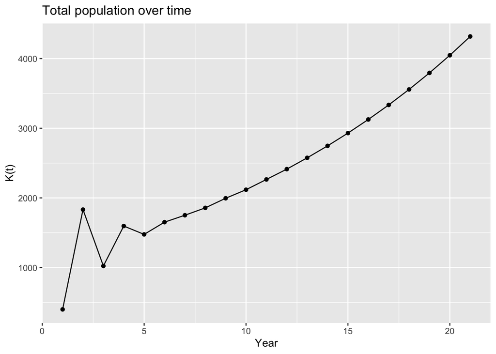

```r
# change Leslie matrix A as requested
A <- matrix(c(0, 5, 10, 0.5*(0.3), 0, 0, 0, 0.5*(0.5), 0.5*(0.2) ), nr = 3, byrow = TRUE)


# set up the intial population vector
K0 <- matrix(c(100,250,50), ncol = 1)

years <- 20
K.projected <- matrix(0, nrow = nrow(A), ncol = years+1)
K.projected[, 1] <- K0

for (i in 1:years)
{
    K.projected[, i + 1] <- A %*% K.projected[,i]
}

# again
# get K in a form that's easier to ggplot
# make into a dataframe, name columns as years and add an age column
Kdf <- as.data.frame(K.projected)
colnames(Kdf) <- seq(1, to = years+1, by = 1)
Kdf <- cbind(stage = c("Eggs", "Juvenile", "Adult"), Kdf)

# get in long format and then add proportion of population in each age group
Klong <- Kdf %>%
  gather(year, population, -stage) %>%
  group_by(year) %>%
  mutate(proportion = population/sum(population),
         stage = as.factor(stage))


# total population by year
tot_pop <- Klong %>%
  group_by(year) %>%
  summarise(pop = sum(population)) %>% ungroup()


# plot total population over time
ggplot(data = tot_pop, aes(x = as.numeric(year), y = pop, group = 1)) +
  geom_point() + geom_line()+
  xlab("Year") + ylab("K(t)")+
  ggtitle("Total population over time")
```

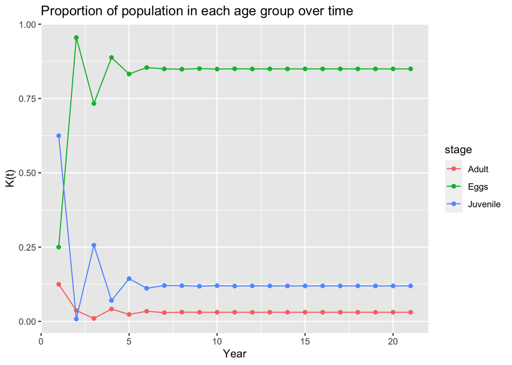

```r
# plot proportion in each age group over time
ggplot(data = Klong, aes(x = as.numeric(year), y = proportion, group = stage, color = stage)) +
  geom_point() + geom_line()+
  xlab("Year") + ylab("K(t)")+
  ggtitle("Proportion of population in each age group over time")
```

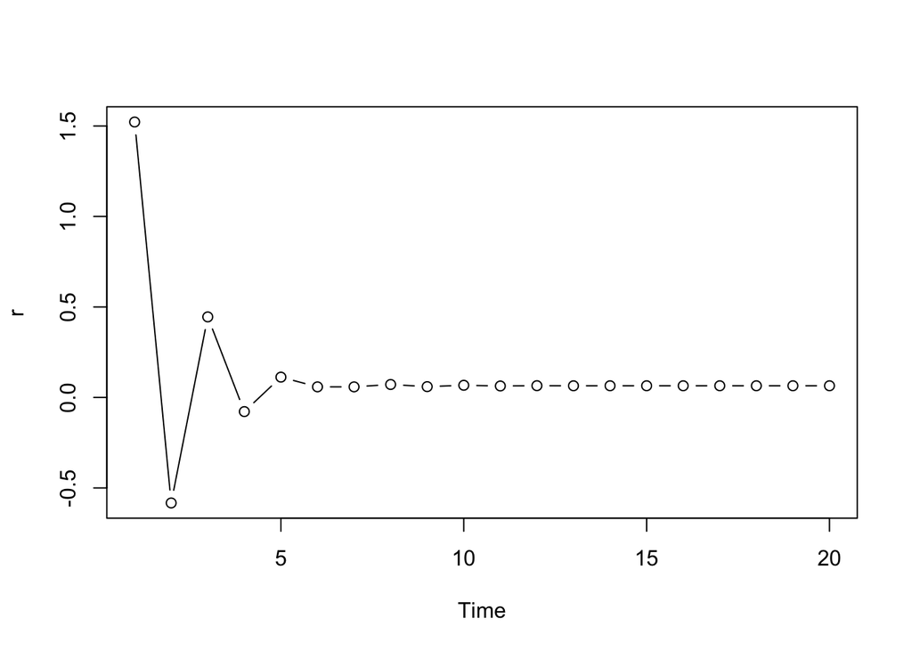

```r
# plot the growth rate r for each year
tot_pop <- tot_pop %>% arrange(as.numeric(year))
lambPop<-log(tot_pop$pop[2:(years+1)]/tot_pop$pop[1:years])
matplot(1:years, lambPop, type="b", pch=1, ylab = "r", xlab = "Time")
```

Again, we see a younger population, but there’s a dramatic drop in the growth rate when we reduce survivorship at all ages. You can further modify the Leslie matrix to answer questions such as: What happens when we only change survivorship from juveniles to adult? What about when we change just the survivorship from eggs to juveniles? Does the adult survival rate have a strong influence on the population’s future? Which transition is more important to the future of the population?